# Insights and visualization only

## **# By this plot we can say that there a good number of covid victims who have been recoverd from the virus, with the given data**

```
Province_State
Andaman and Nicobar Islands       93
Andhra Pradesh                 15412
Arunachal Pradesh                138
Assam                          10426
Bihar                          11498
Name: Recovered, dtype: int64
```

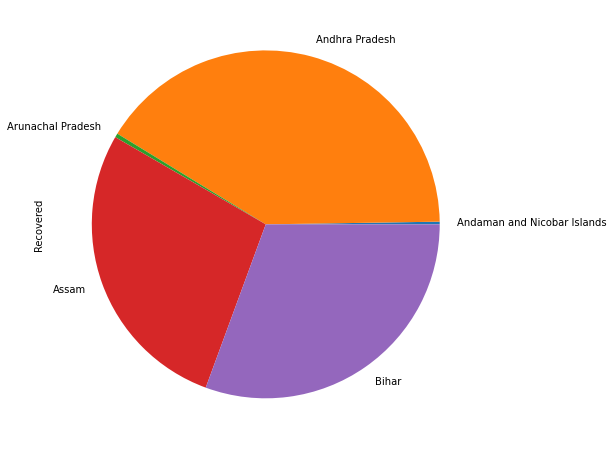

```python
ind_4=India.groupby('Province_State').sum()['Recovered']
ind_4.plot(kind="pie",figsize=(8,8))
print(ind_4)
```

```
Province_State
Andaman and Nicobar Islands       93
Andhra Pradesh                 15412
Arunachal Pradesh                138
Assam                          10426
Bihar                          11498
Name: Recovered, dtype: int64
```

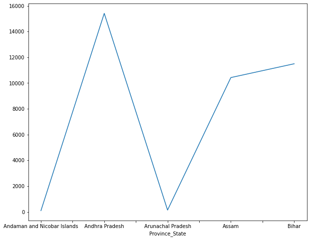

```python
ind_4=India.groupby('Province_State').sum()['Recovered']
ind_4.plot(kind="line",figsize=(10,8))
print(ind_4)
```

```
Province_State
Andaman and Nicobar Islands       70.0
Andhra Pradesh                 13428.0
Arunachal Pradesh                219.0
Assam                           5610.0
Bihar                           5001.0
Name: Active, dtype: float64
```

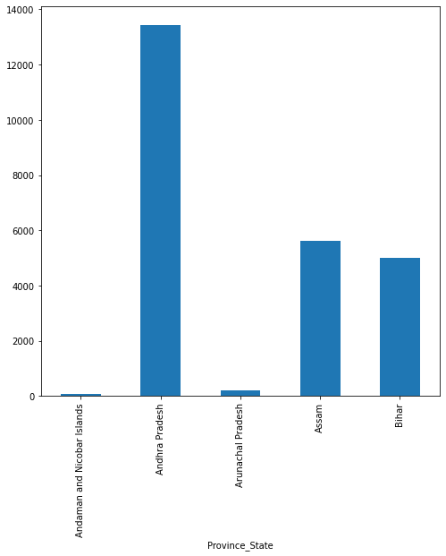

```python
ind_a=India.groupby('Province_State').sum()['Active']
ind_a.plot(kind="bar",figsize=(8,8))
print(ind_a)
```

## More than "60% of the victims" in Arunachal pradesh are still suffering with covid-19 where they had only 359 cases "confirmed" in the given data

```
Province_State
Andaman and Nicobar Islands       70.0
Andhra Pradesh                 13428.0
Arunachal Pradesh                219.0
Assam                           5610.0
Bihar                           5001.0
Name: Active, dtype: float64
```

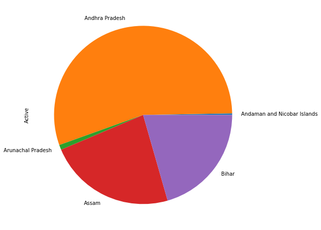

```python
ind_a=India.groupby('Province_State').sum()['Active']
ind_a.plot(kind="pie",figsize=(8,8))
print(ind_a)
```

```
Province_State
Andaman and Nicobar Islands       70.0
Andhra Pradesh                 13428.0
Arunachal Pradesh                219.0
Assam                           5610.0
Bihar                           5001.0
Name: Active, dtype: float64
```

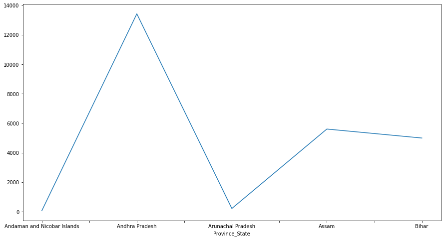

```python
ind_a=India.groupby('Province_State').sum()['Active']
ind_a.plot(kind="line",figsize=(15,8))
print(ind_a)
```

## Granular visualization on the country Brazil due to the COVID-19 pandemic

```python
Brazil=countrywise_data.query('Country_Region=="Brazil" & Confirmed >=0')
```

```python
Brazil.head()
```

|  | FIPS | Admin2 | Province_State | Country_Region | Last_Update | Lat | Long_ | Confirmed | Deaths | Recovered | Active | Combined_Key | Incidence_Rate | Case-Fatality_Ratio |
| --- | --- | --- | --- | --- | --- | --- | --- | --- | --- | --- | --- | --- | --- | --- |
| 3134 | NaN | NaN | Acre | Brazil | 2020-07-13 04:43:04 | -9.0238 | -70.8120 | 16190 | 426 | 9198 | 6566.0 | Acre, Brazil | 1835.736194 | 2.631254 |
| 3139 | NaN | NaN | Alagoas | Brazil | 2020-07-13 04:43:04 | -9.5713 | -36.7820 | 45330 | 1281 | 37460 | 6589.0 | Alagoas, Brazil | 1358.260444 | 2.825943 |
| 3143 | NaN | NaN | Amapa | Brazil | 2020-07-13 04:43:04 | 0.9020 | -52.0030 | 31364 | 474 | 20044 | 10846.0 | Amapa, Brazil | 3708.507788 | 1.511287 |
| 3144 | NaN | NaN | Amazonas | Brazil | 2020-07-13 04:43:04 | -3.4168 | -65.8561 | 83526 | 3039 | 69971 | 10516.0 | Amazonas, Brazil | 2015.298472 | 3.638388 |
| 3176 | NaN | NaN | Bahia | Brazil | 2020-07-13 04:43:04 | -12.5797 | -41.7007 | 105763 | 2483 | 73730 | 29550.0 | Bahia, Brazil | 711.104316 | 2.347702 |

# "Sao Paulo" has recorded the highest number of cases confirmed and "Mato Grosso do Sul" has been the lowest

```
Province_State
Acre                    16190
Alagoas                 45330
Amapa                   31364
Amazonas                83526
Bahia                  105763
Ceara                  136785
Distrito Federal        70712
Espirito Santo          62799
Goias                   36244
Maranhao                98952
Mato Grosso             28411
Mato Grosso do Sul      13197
Minas Gerais            75851
Para                   125714
Paraiba                 60784
Parana                  42537
Pernambuco              72470
Piaui                   32963
Rio Grande do Norte     39421
Rio Grande do Sul       39240
Rio de Janeiro         129684
Rondonia                26728
Roraima                 22225
Santa Catarina          43031
Sao Paulo              371997
Sergipe                 37631
Tocantins               15132
Name: Confirmed, dtype: int64
```

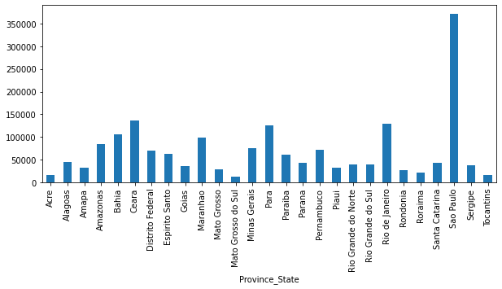

```python
B_C=Brazil.groupby('Province_State').sum()['Confirmed']
B_C.plot(kind="bar",figsize=(10,4))
print(B_C)
```

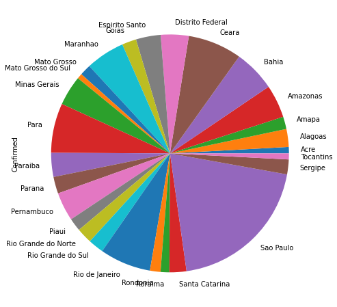

```python
B_C=Brazil.groupby('Province_State').sum()['Confirmed']
B_C.plot(kind="pie",figsize=(15,8))
```

```
Province_State
Acre                     426
Alagoas                 1281
Amapa                    474
Amazonas                3039
Bahia                   2483
Ceara                   6868
Distrito Federal         902
Espirito Santo          2003
Goias                    849
Maranhao                2463
Mato Grosso             1047
Mato Grosso do Sul       161
Minas Gerais            1576
Para                    5289
Paraiba                 1284
Parana                  1045
Pernambuco              5595
Piaui                    936
Rio Grande do Norte     1394
Rio Grande do Sul        962
Rio de Janeiro         11415
Rondonia                 628
Roraima                  396
Santa Catarina           497
Sao Paulo              17848
Sergipe                  984
Tocantins                255
Name: Deaths, dtype: int64
```

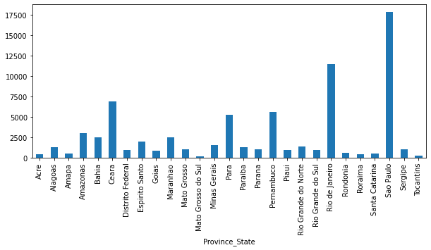

```python
B_d=Brazil.groupby('Province_State').sum()['Deaths']
B_d.plot(kind="bar",figsize=(10,4))
print(B_d)
```

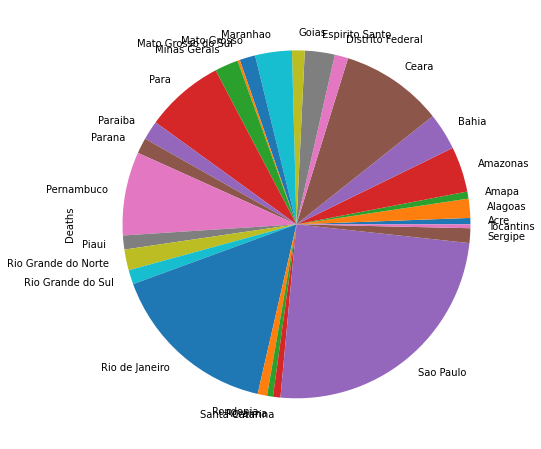

```python
B_d=Brazil.groupby('Province_State').sum()['Deaths']
B_d.plot(kind="pie",figsize=(15,8))
```

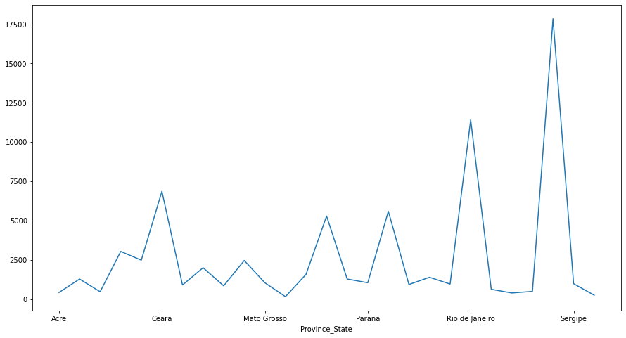

```python
B_d=Brazil.groupby('Province_State').sum()['Deaths']
B_d.plot(kind="line",figsize=(15,8))
```

```
Province_State
Acre                     9198
Alagoas                 37460
Amapa                   20044
Amazonas                69971
Bahia                   73730
Ceara                  110224
Distrito Federal        57262
Espirito Santo          41671
Goias                   10480
Maranhao                77815
Mato Grosso             11660
Mato Grosso do Sul       8678
Minas Gerais            49769
Para                   112237
Paraiba                 22292
Parana                  13374
Pernambuco              50850
Piaui                   31520
Rio Grande do Norte      2904
Rio Grande do Sul       32815
Rio de Janeiro         110061
Rondonia                15755
Roraima                  8191
Santa Catarina          33758
Sao Paulo              220974
Sergipe                 22903
Tocantins                9247
Name: Recovered, dtype: int64
```

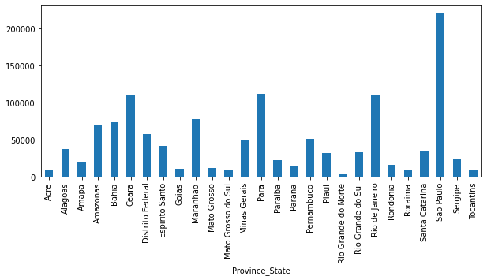

```python
B_R=Brazil.groupby('Province_State').sum()['Recovered']
B_R.plot(kind="bar",figsize=(10,4))
print(B_R)
```

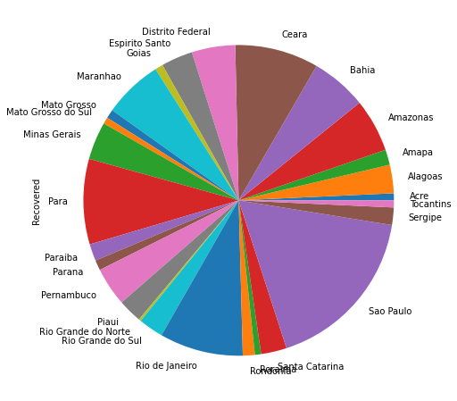

```python
B_R=Brazil.groupby('Province_State').sum()['Recovered']
B_R.plot(kind="pie",figsize=(15,8))
```

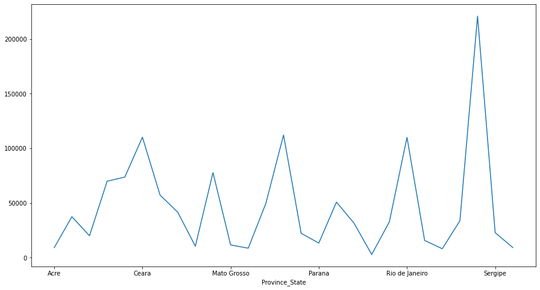

```python
B_R=Brazil.groupby('Province_State').sum()['Recovered']
B_R.plot(kind="line",figsize=(15,8))
```

```
Province_State
Acre                     6566.0
Alagoas                  6589.0
Amapa                   10846.0
Amazonas                10516.0
Bahia                   29550.0
Ceara                   19693.0
Distrito Federal        12548.0
Espirito Santo          19125.0
Goias                   24915.0
Maranhao                18674.0
Mato Grosso             15704.0
Mato Grosso do Sul       4358.0
Minas Gerais            24506.0
Para                     8188.0
Paraiba                 37208.0
Parana                  28118.0
Pernambuco              16025.0
Piaui                     507.0
Rio Grande do Norte     35123.0
Rio Grande do Sul        5463.0
Rio de Janeiro           8208.0
Rondonia                10345.0
Roraima                 13638.0
Santa Catarina           8776.0
Sao Paulo              133175.0
Sergipe                 13744.0
Tocantins                5630.0
Name: Active, dtype: float64
```

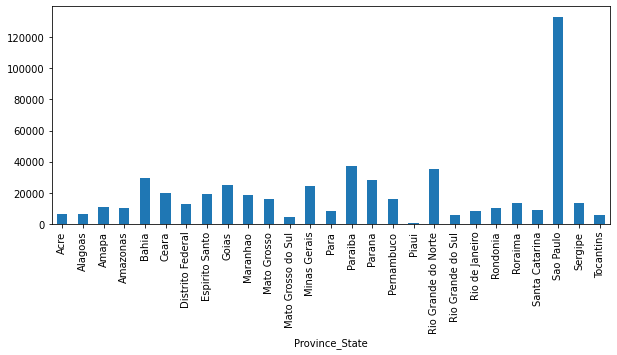

```python
B_a=Brazil.groupby('Province_State').sum()['Active']
B_a.plot(kind="bar",figsize=(10,4))
print(B_a)
```

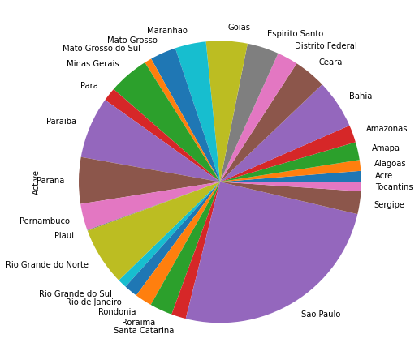

```python
B_a=Brazil.groupby('Province_State').sum()['Active']
B_a.plot(kind="pie",figsize=(15,8))
```

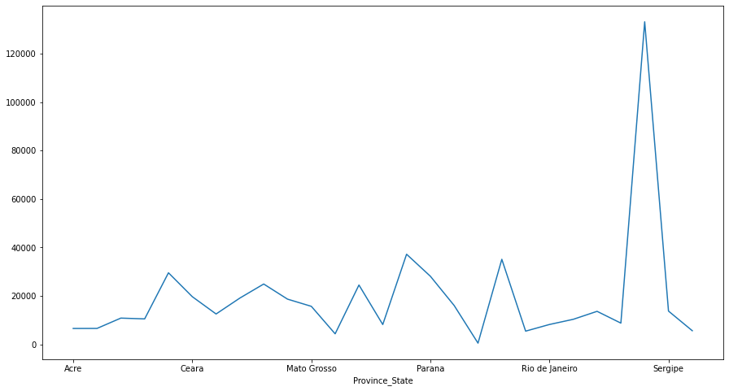

```python
B_a=Brazil.groupby('Province_State').sum()['Active']
B_a.plot(kind="line",figsize=(15,8))
```